# Process and analyze OED etymologies

Bodo Winter

14/10/2021

## Setup

Load packages:

```r
library(tidyverse, quietly = TRUE)
library(brms, quietly = TRUE)
library(effsize, quietly = TRUE)
```

Load data:

```r
OED <- read_csv('../additional_data/OED_all.csv')
```

Check structure:

```r
OED
```

```
## # A tibble: 287,341 × 11
##        ID entry     URL   lemma first_attest etym_type direct_etymon path1 path2
##     <dbl> <chr>     <chr> <chr>        <dbl> <chr>     <chr>         <chr> <chr>
##  1      1 A, n.     http… A             1020 <NA>       <NA>         <NA>  <NA>
##  2 365363 a, pron.  http… a             1224 variant   "English \"h… Engl… <NA>
##  3      4 a, adj.   http… a             1159 variant   "English \"o… Engl… <NA>
##  4      8 a, prep.1 http… a             1020 variant   "English \"o… Engl… <NA>
##  5      9 a, prep.2 http… a             1275 variant   "English \"o… Engl… <NA>
##  6     11 a, conj.  http… a             1335 variant   "English \"a… Engl… <NA>
##  7     13 a, int.1  http… a             1175 imitative  <NA>         <NA>  <NA>
##  8 270917 a, int.2  http… a             1440 variant   "English \"a… Engl… Fren…
##  9 276358 A1, adj.  http… A1            1776 compound  "English \"A… Engl… <NA>
## 10 278754 A2, n.    http… A2            1999 compound  "English \"a… Engl… <NA>
## # … with 287,331 more rows, and 2 more variables: path3 <chr>, word <chr>
```

Count `etym_type` column content:

```r
OED %>% count(etym_type, sort = TRUE)
```

```
## # A tibble: 19 × 2
##    etym_type             n
##    <chr>             <int>
##  1 derivative       105485
##  2 borrowing         68691
##  3 compound          38286
##  4 <NA>              18389
##  5 borrowingHybrid   14461
##  6 conversion        11963
##  7 variant            6469
##  8 inherited          4631
##  9 properName         4505
## 10 properNameHybrid   3841
## 11 shortening         3263
## 12 unknown            2540
## 13 uncertain          2293
## 14 imitative           909
## 15 blend               691
## 16 backformation       475
## 17 acronym             271
## 18 arbitrary            92
## 19 initialism           86
```

There’s a lot of categories. The following conversions should happen: 1) Merge `uncertain` and `uknown` together. 2) Merge `properName` and `properNameHybrid`. 3) Merge `borrowingHybrid` and `borrwing`. 4) Merge marginal word formation processes into an `other` category.

```r
others <- c('arbitrary', 'initialism', 'acronym', 'backformation',
            'shortening', 'variant', 'inherited', 'blend')

OED <- mutate(OED,
              etym_simplified = ifelse(etym_type == 'unknown',
                                       'uncertain', etym_type),
              etym_simplified = ifelse(etym_simplified == 'properNameHybrid',
                                       'properName', etym_simplified),
              etym_simplified = ifelse(etym_simplified == 'borrowingHybrid',
                                       'borrowing', etym_simplified),
              etym_simplified = ifelse(etym_simplified %in% others,
                                       'other', etym_simplified))

# Count again:

OED %>% count(etym_simplified, sort = TRUE)
```

```
## # A tibble: 9 × 2
##   etym_simplified      n
##   <chr>            <int>
## 1 derivative      105485
## 2 borrowing        83152
## 3 compound         38286
## 4 <NA>             18389
## 5 other            15978
## 6 conversion       11963
## 7 properName        8346
## 8 uncertain         4833
## 9 imitative          909
```

Get rid of NAs:

```r
OED <- filter(OED,
              !is.na(etym_simplified))
```

We have to map OED, which is organized in terms of senses, to the remaining data. For this we need to collapse the sense information. For this, let’s do a majority vote where word senses are combined:

```r
OED_counts <- OED %>%
  count(word, etym_simplified)
```

Make it wide:

```r
OED_wide <- OED_counts %>%
  pivot_wider(names_from = etym_simplified, values_from = n, values_fill = 0)
```

The order does matter for cases where there is the same number. Let’s put `other` first, the most hotchpotch category, then everything else in order of n of overall category (see `etym_simplified` counts above):

```r
OED_wide <- select(OED_wide,
                   word,
                   other, derivative, borrowing, compound,
                   conversion, properName, uncertain, imitative)
```

Get whatever is the maximum:

```r
these_maxes <- apply(OED_wide[, 2:ncol(OED_wide)], MARGIN = 1, FUN = which.max)
```

Get the corresponding etymologies:

```r
etym_set <- colnames(select(OED_wide, other:imitative))
OED_wide$main_etym <- etym_set[these_maxes]
```

Get rid of the remaining columns:

```r
OED_wide <- select(OED_wide, word, main_etym)
```

Count:

```r
nrow(OED_wide)
```

```
## [1] 235862
```

## Merge with iconicity ratings and analyze

Load iconicity ratings:

```r
icon <- read_csv('../ratings/iconicity_ratings.csv')
```

Merge this with iconicity ratings:

```r
icon <- left_join(icon, OED_wide)
```

For how many do we have the etymological information:

```r
sum(!is.na(icon$main_etym)) / nrow(icon)
```

```
## [1] 0.9444597
```

Change `properName` so that it is more printable for later plotting:

```r
icon <- mutate(icon,
               main_etym = ifelse(main_etym == 'properName',
                                  'proper name', main_etym))
```

Check how many words this analysis is for:

```r
nrow(icon)
```

```
## [1] 14566
```

Get rid of the ones that are `NA`:

```r
icon <- filter(icon,
               !is.na(main_etym))
```

Compute average and standard deviations of iconicity:

```r
icon_avgs <- icon %>%
  group_by(main_etym) %>%
  summarize(M = mean(rating),
            SD = sd(rating),
            M = round(M, 1),
            SD = round(SD, 1)) %>%
  arrange(desc(M))

# Show:

icon_avgs
```

```
## # A tibble: 8 × 3
##   main_etym       M    SD
##   <chr>       <dbl> <dbl>
## 1 imitative     5.4   0.9
## 2 uncertain     4.4   0.9
## 3 conversion    4.3   1
## 4 compound      4     0.8
## 5 other         4     0.9
## 6 derivative    3.8   0.9
## 7 borrowing     3.5   0.8
## 8 proper name   3.5   0.9
```

Convert to factor and order it so that it is in order of mean iconicity for plotting:

```r
icon <- mutate(icon,
               main_etym = factor(main_etym, levels = icon_avgs$main_etym))
```

Make a plot of this:

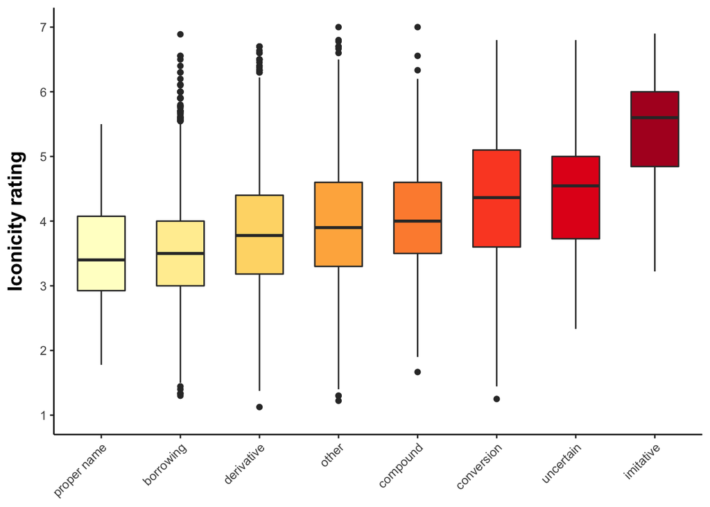

```r
# Plot basics:

OED_p <- icon %>%
  ggplot(aes(x = reorder(main_etym, rating), y = rating, fill = main_etym)) +
  geom_boxplot(width = 0.6)

# Scale and axes:

OED_p <- OED_p +
  scale_fill_brewer(palette = 'YlOrRd', direction = -1) +
  coord_cartesian(ylim = c(1, 7)) +
  scale_y_continuous(breaks = 1:7) +
  ylab('Iconicity rating') +
  xlab(NULL)

# Cosmetics:

OED_p <- OED_p +
  theme_classic() +
  theme(axis.text.x = element_text(angle = 45, hjust = 1),
        axis.title.y = element_text(face = 'bold', size = 14,
                                    margin = margin(r = 10)),
        legend.position = 'none')

# Show and save:

OED_p
```

```r
ggsave('../figures/OED_iconicity.pdf', plot = OED_p,
       width = 6.5, height = 4)
```

## Bayesian model of imitative versus not imitative

Weakly informative priors on slope coefficient:

```r
priors <- c(prior(normal(0, 0.5), class = b))
```

For MCMC settings (will be used only for models that find it hard to converge):

```r
mcmc_controls <- list(adapt_delta = 0.999,
                      max_treedepth = 13)
```

We will convert the SDs to the range 0 to 1. I used this as a guide:

https://stackoverflow.com/questions/929103/convert-a-number-range-to-another-range-maintaining-ratio

```r
# mins and maxes:

sd_min <- min(icon$rating_sd)
sd_max <- max(icon$rating_sd)

# convert:

icon <- mutate(icon,
               w = (rating_sd - sd_min) / (sd_max - sd_min),

               # to invert (so that max SD = lowest weight):

               w = w * -1 + 1,

               # renormalize these weights to have mean 1:

               w = w / mean(w))

# check:

mean(icon$w)
```

```
## [1] 1
```

```r
arrange(icon, desc(w))
```

```
## # A tibble: 13,757 × 8
##    word        n_ratings     n prop_known rating rating_sd main_etym      w
##    <chr>           <dbl> <dbl>      <dbl>  <dbl>     <dbl> <fct>      <dbl>
##  1 swoosh             11    11      1       7        0     compound    2.53
##  2 wiggle              9     9      1       7        0     other       2.53
##  3 swish              10    10      1       6.9      0.316 imitative   2.26
##  4 oomph               9     9      1       6.89     0.333 imitative   2.25
##  5 wheeze              9     9      1       6.89     0.333 borrowing   2.25
##  6 discernment         8     9      0.889   1.12     0.354 derivative  2.23
##  7 purr               10    10      1       6.8      0.422 uncertain   2.18
##  8 sigh               10    10      1       6.8      0.422 other       2.18
##  9 squeak             10    10      1       6.8      0.422 conversion  2.18
## 10 bang                9     9      1       6.78     0.441 conversion  2.16
## # … with 13,747 more rows
```

```r
arrange(icon, w)
```

```
## # A tibble: 13,757 × 8
##    word       n_ratings     n prop_known rating rating_sd main_etym       w
##    <chr>          <dbl> <dbl>      <dbl>  <dbl>     <dbl> <fct>       <dbl>
##  1 effortless        10    10      1       3.6       2.99 derivative 0
##  2 smatter            8     9      0.889   3.5       2.93 conversion 0.0518
##  3 we                10    10      1       2.9       2.85 other      0.121
##  4 outcome            9    10      0.9     3.56      2.83 derivative 0.132
##  5 windmill          11    11      1       4.27      2.83 compound   0.133
##  6 farmhouse         10    10      1       3.3       2.83 compound   0.134
##  7 bread             10    10      1       3.8       2.82 other      0.143
##  8 gunpowder          9    10      0.9     3.89      2.80 compound   0.157
##  9 shoreline          9     9      1       3.89      2.80 compound   0.157
## 10 Tartarus           9    11      0.818   3.89      2.80 borrowing  0.157
## # … with 13,747 more rows
```

Create an imitation versus rest variable:

```r
icon <- mutate(icon,
               imit = ifelse(main_etym == 'imitative', 'imitative', 'not imitative'))
```

Averages:

```r
icon %>%
  group_by(imit) %>%
  summarize(M = mean(rating),
            SD = sd(rating))
```

```
## # A tibble: 2 × 3
##   imit              M    SD
##   <chr>         <dbl> <dbl>
## 1 imitative      5.40 0.903
## 2 not imitative  3.76 0.904
```

Cohen’s d:

```r
with(icon, cohen.d(rating ~ imit))
```

```
##
## Cohen's d
##
## d estimate: 1.813627 (large)
## 95 percent confidence interval:
##    lower    upper
## 1.537809 2.089445
```

Create a model of this:

```r
imit_mdl <- brm(rating | weights(w) ~ 1 + imit,
               data = icon,
               prior = priors,

               # MCMC settings:

               seed = 666,
               cores = 4,
               warmup = 2000, iter = 4000, chains = 4)
```

```
## Trying to compile a simple C file
```

[output not shown]

```r
# Save:

save(imit_mdl, file = '../models/OED_imitative_mdl.RData')
```

Check model:

```r
imit_mdl
```

```
##  Family: gaussian
##   Links: mu = identity; sigma = identity
## Formula: rating | weights(w) ~ 1 + imit
##    Data: icon (Number of observations: 13757)
##   Draws: 4 chains, each with iter = 4000; warmup = 2000; thin = 1;
##          total post-warmup draws = 8000
##
## Population-Level Effects:
##                  Estimate Est.Error l-95% CI u-95% CI Rhat Bulk_ESS Tail_ESS
## Intercept            5.49      0.12     5.25     5.73 1.00     7021     5864
## imitnotimitative    -1.73      0.12    -1.97    -1.49 1.00     7027     5858
##
## Family Specific Parameters:
##       Estimate Est.Error l-95% CI u-95% CI Rhat Bulk_ESS Tail_ESS
## sigma     0.99      0.01     0.98     1.00 1.00     7887     5749
##
## Draws were sampled using sampling(NUTS). For each parameter, Bulk_ESS
## and Tail_ESS are effective sample size measures, and Rhat is the potential
## scale reduction factor on split chains (at convergence, Rhat = 1).
```

Perform hypothesis test of imitative versus non-imitative:

```r
hypothesis(imit_mdl, 'imitnotimitative > 0')
```

```
## Hypothesis Tests for class b:
##               Hypothesis Estimate Est.Error CI.Lower CI.Upper Evid.Ratio
## 1 (imitnotimitative) > 0    -1.73      0.12    -1.94    -1.52          0
##   Post.Prob Star
## 1         0
## ---
## 'CI': 90%-CI for one-sided and 95%-CI for two-sided hypotheses.
## '*': For one-sided hypotheses, the posterior probability exceeds 95%;
## for two-sided hypotheses, the value tested against lies outside the 95%-CI.
## Posterior probabilities of point hypotheses assume equal prior probabilities.
```